# Chapter 02: Functions

Author

Khiem Nguyen – khiem.nguyen@glasgow.ac.uk

# 1 Basic Syntax

## 1.1 An example of a user-defined function

The most basic syntax to define a user-defined function

Listing 1: Most basic syntax to define a user-defined function.

```
function_basic_syntax.cpp
```

```cpp
return_type function_name() // This is the function header
                            // (tells the compiler about the existence
                            //  of the function)
{
    // This is the function body
    // (tells the compiler what the function does)
}
// This file is not compilable as it has no main() function
```

- The `function_name` is the name (identifier) of your user-defined function.
- The parentheses after the identifier tell the compiler that we’re defining a function.

## 1.2 Define a function and call the function

- Of course, after defining the function, we can call it multiple times.

Listing 2: Define function and call function. Filename: `call_function.cpp`

```cpp
#include <iostream> // for std::cout

void say_hello()    // user-defined function
{
    std::cout << "In say_hello(): Hello there!\n";
}

int main()          // Definition of function main()
{
    std::cout << "Starting main()\n";
    say_hello(); // say_hello() called for the first time
    say_hello(); // say_hello() called for the second time
    std::cout << "Ending main()\n";
    return 0;
}
```

## 1.3 Functions can call functions that call other functions

Listing 3: Function can call other functions

```cpp
#include <iostream> // for std::cout
void do_thing_B() {
    std::cout << "In do_thing_B()\n";
}
void do_thing_A() {
    std::cout << "Starting do_thing_A()\n";
    do_thing_B();
    std::cout << "Ending do_thing_A()\n";
}
// Definition of function main()
int main() {
    std::cout << "Starting main()\n";
    do_thing_A();
    std::cout << "Ending main()\n";
    return 0;
}
```

## 1.4 Nested functions are not supported

- A function whose definition is placed inside another function is a **nested function**.
- Unlike Python and MATLAB, functions cannot be nested in C++.

The following program is **not legal**:

```cpp
#include <iostream>

int main()
{
    void foo() // Illegal: this function is nested inside function main()
    {
        std::cout << "foo!\n";
    }
    foo(); // function call to foo()
    // "foo" is a meaningless word that is often used
    // as a placeholder name for a function or variable
    // when the name is unimportant to the demonstration
    // of some concept.
    return 0;
}
// Note: The above code will not compile because C++
// does not allow nested functions.
```

# 2 Function retrun values (value-returning functions)

## 2.1 Return values

When we write a user-defined function, we get to determine whether the function will return a value back to the caller or not.

- Indicate what type of value will be returnd (**return type**)
- Use a **return statement** to indicate the specific value being returned to the caller.

```cpp
return_type function_name()
{
    // function body
    return return_expression;
}
```

When the return statement is executed:

1. The **return expression** is evaluated to produce a value.
2. The value produced by the return expression is copied back to the caller. This copy is called the **return value** of the function.
3. The function exits, and control returns to the caller.

**Summary**

The **return expression** produces the value to be returned. The return value is a copy of that value.

## 2.2 Return values: Code Demonstration

Listing 5: Return value in a function

```
return_value.cpp
```

```cpp
#include <iostream>

int get_value_from_user() // this function now returns an integer value
{
    std::cout << "Enter an integer: ";
    int input{};
    std::cin >> input;

    return input; // return the value the user entered back to the caller
}

int main()
{
    // initialize num with the return value of get_value_from_user()
    int num { get_value_from_user() };

    std::cout << num << " doubled is: " << num * 2 << '\n';

    return 0;
}
```

## 2.3 Revisiting `main()`

In C++, there are two special requirements for main():

- `main()` is required to return an `int`.
- Explicit function calls to `main()` are disallowed.

Listing 6: This program will produce compile error!!!

```cpp
void foo()
{
    main(); // Compile error: main not allowed to be called explicitly
}

void main() // Compile error: main not allowed to have non-int return type
{
    foo();
}
```

## 2.4 Functions can only return a single value

- A value-returning function can only return a single value back to the caller each time it is called.
- There are various ways to work around the limitation of functions only being able to return a single value, which we’ll cover in future lessons.

## 2.5 Don’t Repeat Yourself (DRY)

*Golden Rule*  
**Don’t Repeat Yourself** (DRY)

Listing 7: This program violates Don’t Repeat Yourself and can be rewritten

```cpp
#include <iostream>




int main()
{
    int x{};
    std::cout << "Enter an integer: ";
    std::cin >> x;
    int y{};
    std::cout << "Enter an integer: ";
    std::cin >> y;
    std::cout << x << " + " << y << " = " << x + y << '\n';

    return 0;
}
```

## 2.6 Don’t Repeat Yourself (DRY)

We can rewrite the above by define a function and reuse the function multiple times.

Listing 8: Rewrite the above program to conform with DRY

```cpp
#include <iostream>

int get_value_from_user()
{
    std::cout << "Enter an integer: ";
    int input{};
    std::cin >> input;

    return input;
}

int main()
{
    int x{ get_value_from_user() }; // first call to get_value_from_user
    int y{ get_value_from_user() }; // second call to get_value_from_user

    std::cout << x << " + " << y << " = " << x + y << '\n';

    return 0;
}
```

# 3 Void functions (non-value returning functions)

## 3.1 Void return values

To tell the compiler that a function does not return a value, a return type of `void` is used.

Listing 9: non-value returning functions return void

```cpp
#include <iostream>
#include <string>       // to use std::string
// void means the function does not return a value to the caller
void hi_somebody(std::string name)
{
    std::cout << "Hi " << name << '\n';

    // This function does not return a value so no return statement is needed
}
int main()
{
    hi_somebody("Alice"); // function hi_somebody() is called, no value is returned
    hi_somebody("Catherine");
    return 0;
}
```

## 3.2 Void functions do not need a return statement

- A void function will automatically return to the caller at the end of the function. No return statement is required.
- A return statement (with no return value) can be used in a void function – such a statement will cause the function to return to the caller at the point where the return statement is executed.
- Consequently, putting an empty return statement at the end of a void function is redundant.

Listing 10: **return** in a void function will cause the function to return to the caller

```cpp
#include <iostream>
void say_hi()   // void means the function does not return a value to the caller
{
    std::cout << "Hi" << '\n';

    std::cout << "Khiem Nguyen" << '\n';
    return; // tell compiler to return to the caller
    /* this is redundant since the return will happen
       at the end of the function anyway! */

    std::cout << "This line will never be executed" << '\n';
}   // function will return to caller here

int main()
{
    say_hi();
    std::cout << "Back in main()" << '\n';
    return 0;
}
```

## 3.3 Returning a value from a void function is a compile error

- Obviously, trying to return a value from a non-value returning function will result in a compilation error.
- This needs no explanation, just common sense.

Listing 11: Returning a value from a void function will result in a compilation error

```cpp
void say_hi() // This function is non-value returning
{
    std::cout << "In say_hi()" << '\n';

    return 5; // compile error: we're trying to return a value
}
```

# 4 Introduction to function parameters and arguments

## 4.1 Function parameters and arguments

### 4.1.1 Function parameter

- A **function parameter** is a variable used in the header of a function.
- Function parameters work almost identically to variables defined inside the function, but with one difference.
- Function parameters are initialized with a value provided by the caller of the function.

### 4.1.2 Argument

An argument is a value that is passed from the caller to the function when a function call is made.

```cpp
say_hello();            // this call has no arguments
print_value(6);         // 6 is the argument passed to function printValue()
add(2.0, 3.0);          // 2.0 and 3.0 are the arguments passed to function add()
```

## 4.2 Function parameters: Examples

Listing 12: Different functions with different number of parameters

```cpp
// This function takes no parameters
// It does not rely on the caller for anything
void say_hello()
{
    std::cout << "Hello World\n";
}
// This function takes one integer parameter named x
// The caller will supply the value of x
void print_value(double x)
{
    std::cout << x << '\n';
}
// This function has two integer parameters, one named x, and one named y
// The caller will supply the value of both x and y
int add(double x, double y)
{
    return x + y;
}
/* This code snippet cannot be compiled. */
```

## 4.3 How parameters and arguments work toghether

- When a function is called, all of the parameters of the function are created as variables.
- The value of each of the arguments is copied into the matching parameter (using copy initialization).
- This process is called **pass by value**.
- Function parameters that utilize *pass by value* are called **value parameters**.

## 4.4 Call a function with the process of pass-by-value

Listing 13: Call a function by using the process **pass by value**

```cpp
#include <iostream>

// This function has two integer parameters, one named x, and one named y
// The values of x and y are passed in by the caller
void swap(int x, int y)
{
    int z { x };
    x = y;
    y = z;
    std::cout << "x = " << x << '\n';
    std::cout << "y = " << y << '\n';
}

int main()
{

    swap(6, 7); // This function call has two arguments, 6 and 7

    int x { 100 };
    int y { 200 };
    swap(x, y); // This function call has two arguments, x and y

    std::cout << "Back in main(), x is still: " << x << '\n';
    std::cout << "Back in main(), y is still: " << y << '\n';

    return 0;
}
```

## 4.5 Call a function with the process of pass-by-value

Listing 14: Combine what we have learned so far to write a stupid program

```cpp
#include <iostream>
// using namespace std;
int get_value_from_user()
{
    cout << "Enter an integer: ";
    int input{};
    std::cin >> input;

    return input;
}

void print_double(int value) // This function now has an integer parameter
{
    std::cout << value << " doubled is: " << value * 2 << '\n';
}

int main()
{
    int num { get_value_from_user() };
    print_double(num);

    // We can also combine two statements into one.
    print_double(get_value_from_user());
    return 0;
}
```

## 4.6 Call a function with the process of pass-by-value: More examples

Listing 15: Call a function by using the process **pass by value**: More examples

```cpp
#include <iostream>

int add(int x, int y)
{
    return x + y;
}

int multiply(int z, int w)
{
    return z * w;
}

int main()
{
    std::cout << add(4, 5) << '\n';         // within add() x=4, y=5, so x+y=9
    std::cout << add(1 + 2, 3 * 4) << '\n'; // within add() x=3, y=12, so x+y=15

    int a{ 5 };
    std::cout << add(a, a) << '\n';         // evaluates (5 + 5)

    std::cout << add(1, multiply(2, 3)) << '\n';    // evaluates 1 + (2 * 3)
    std::cout << add(1, add(2, 3)) << '\n';         // evaluates 1 + (2 + 3)

    return 0;
}
```

# 5 Introduction to local scope

## 5.1 Local variables

- Variables defined inside the body of a function are called local variables.
- Function parameters are also generally considered to be local variables.

Listing 16: Local variables

```cpp
int add(int x, int y) // function parameters x and y are local variables
{
    int z{ x + y };         // z is a local variable

    return z;
}
```

## 5.2 Local variable lifetime

- Function parameters are created and initialized when the function is entered, and variables within the function body are created and initialized at the point of definition.
- The natural follow-up question is, “So when is an instantiated variable destroyed?”.

**Answer**

> Local variables are destroyed in the opposite order of creation at the end of the set of curly braces in which it is defined (or for a function parameter, at the end of the function).

Listing 17: Lifetime of local variables

```cpp
double add(double x, double y)       // x and y created and initialized here
{
    double z{ x + y };         // z created and initialized here

    return z;
} // z, y, and x destroyed here
```

## 5.3 Local variable lifetime: Example

Listing 18: Local variable lifetime: Example

```cpp
#include <iostream>
#include <string>

// my_name is not in scope anywhere in this function
void say_hello(std::string name)
{
    // name's lifetime begins here
    std::cout << "Hello, " << name << "!\n";
}   // name's lifetime ends here

int main()
{
    std::string my_name { "Khiem" };    // my_name's lifetime begins here

    say_hello(my_name); // my_name is still alive during this function call

    return 0;
}       // my_name's lifetime ends here
```

## 5.4 What happens when an object is destroyed?

- In most cases, nothing happens. The destroyed object simply becomes invalid.
- At some point after destruction, the memory used by the object will be deallocated (freed up for reuse).

### 5.4.1 Destructor

- If the object is a class type object, prior to destruction, a special function called a destructor is invoked.
- We study destructors when we study “**Object-oriented Programming**” (**OOP**).

## 5.5 Local scope (block scope)

### 5.5.1 Scope

- An identifier’s **scope** determines where the identifier can be seen and used within the source code.
- When an identifier can be seen and used, we say it is in **scope**.
- When an identifier can not be seen, we can not use it, and we say it is **out of scope**.

### 5.5.2 Local scope

- The identifier of a local variable has **local scope**.
- An identifier with local scope (technically called block scope) is usable from the point of definition to the end of the innermost pair of curly braces containing the identifier (or for function parameters, at the end of the function).

> **Scope is a compile-time property**, and trying to use an identifier when it is not in scope will result in a compile error.

## 5.6 Local scope: Example 01

This program compiles fine and outputs what we expected.

Listing 19: Local scope: Example 01

```cpp
#include <iostream>

// x is not in scope anywhere in this function
void do_useless_thing(double number = 0.0)
{
    int x{ 42 }; // x enters scope here and can be used within this function

    // number and x can be used here
    std::cout << "Number: " << number << ", x: " << x << "\n";
} // x and number go out of scope here and can no longer be used

int main()
{
    // x can not be used here because it's not in scope yet

    int x{ 0 }; // x enters scope here and can now be used within this function
    do_useless_thing(15.5);     // x is still alive during this function call
    do_useless_thing();         // x is still alive during this function call

    return 0;
} // x goes out of scope here and can no longer be used
```

## 5.7 Local scope: Example 02

Let us look at this program.

Listing 20: Local scope: Example 02

```cpp
// This program will not compile due to scope violation.
// See compile error related to variable 'x'.
#include <iostream>

// Demonstrates local variable scope within a function.
void do_useless_thing(double number = 0.0)
{
    {   // NOTE: New inner scope begins here
        int x{ 42 }; // x enters scope here and can be used within this function
        // number and x can be used here
        std::cout << "Number: " << number << ", x: " << x << "\n";
    }   // x's scope ends here but number is still in scope

    std::cout << "Number again: " << number << "\n";
    std::cout << "Trying to access x here would cause a compile error.\n";

    std::cout << "x: " << x << "\n";    // This will cause a compile error
}

int main()
{
    do_useless_thing(15.5);
    do_useless_thing();
    return 0;
}
```

## 5.8 Scope versus Lifetime

In programming in general, **scope** and **lifetime** are two closely related but distinct concepts that determine how and when a variable can be used.

The simplest way to remember:

- **Scope** is about **Visibility** (Where can I see this variable in the code?).
- **Lifetime** is about **Existence** (How long does this variable stay in memory?).

## 5.9 Scope versus Lifetime

### 5.9.1 Scope (the “**where**”)

- **Scope** refers to the region of your program’s source code where a variable’s name is recognized and can be used.
- If you try to access a variable outside its scope, the compiler will throw an error saying the variable is undefined.
- Therefore, **Scope** is a **compile-time property** in C/C++.

> **Remark**: Other languages, we have Dynamic Scope (versus Static Scope as in C++) which is a runtime property

### 5.9.2 Lifetime

- **Lifetime** (also called storage duration) refers to the time interval during which the variable actually occupies a physical spot in your computer’s memory.
- It starts when the memory is allocated and ends when it is reclaimed by the system.
- Therefore, **Lifetime** is a **run-time property**.

## 5.10 Scope versus Lifetime: Example

Listing 21: Scope versus Lifetime

```cpp
void second_function() {
    // x is ALIVE in memory, but OUT OF SCOPE here.
    // I cannot access 'x' directly.
}
void first_function() {
    int x = 10; // 'x' scope starts here
    second_function();
    // 'x' scope continues here
} // 'x' scope and lifetime end here

int main() {
    first_function();
    return 0;
}
```

But I don’t think you actually believe me. Let me prove this to you!

## 5.11 Scope versus Lifetime: Example

Listing 22: Prove that Scope and Lifetime are different concepts

```cpp
#include <iostream>

void second_function(int* pointer_to_x) {
    // We cannot use the name 'x' here (Out of Scope)
    // But we can look at the memory address we were given
    std::cout << "Inside second_function:" << std::endl;
    std::cout << "Value at memory address: " << *pointer_to_x << std::endl;
    std::cout << "Memory address: " << pointer_to_x << std::endl;
    // std::cout << x;
}

void first_function() {
    int x = 10; // 'x' starts its lifetime here
    // We pass the ADDRESS of x (&x) to the next function
    second_function(&x);
} // 'x' dies here

int main() {
    first_function();
    return 0;
}
```

I hope you believe me now. Actually, you can debug the code in the last slide and still see that variable `x` is alive during the execution of `second_function()`.

# 6 Forward declarations and definitions

## 6.1 Quick introduction

Listing 23: Seemingly innocent sampe program that gives compile error

```cpp
// This program will not compile because 'add' is used before it is declared.
// TO FIX THIS, we need to either add a forward declaration of 'add' before main(),
// or move the definition of 'add' above main().
#include <iostream>
int main()
{
    std::cout << "The sum of 3 and 4 is: " << add(3.0, 4.0) << '\n';
    return 0;
}

float add(float x, float y)
{
    return x + y;
}
```

- This program doesn’t compile is as the compiler compiles the contents of code files sequentially.
- When the compiler reaches the function call `add()` in `main()`, it does not know what `add` is.

## 6.2 Fix the “innocent” program – Option 1: Reorder the function definitions

Listing 24: Reorder the function definitions to fix the innocent program.

```
reorder_function_defs.cpp
```

```cpp
#include <iostream>

int add(int x, int y)
{
    return x + y;
}

int main()
{
    std::cout << "The sum of 3 and 4 is: " << add(3, 4) << '\n';
    return 0;
}
```

- The fixing is simple.
- But, what happens if we have *many functions* and *the functions may call each other*.
- We must figure out which functions call which other functions.

## 6.3 Fix the “innocent” program – Option 1: Use a forward declaration

Listing 25: Use forward decleration to fix the innocent program

```
with_forward_declaration.cpp
```

```cpp
#include <iostream>

int add(int x, int y); // forward declaration of add() (using a function declaration)

int main()
{
    // this works because we forward declared add() above
    std::cout << "The sum of 3 and 4 is: " << add(3, 4) << '\n';
    return 0;
}

int add(int x, int y) // even though the body of add() isn't defined until here
{
    return x + y;
}
```

## 6.4 Why forward declarations!!!

- Why would we use a **forward declaration** if we could just reorder the functions to make our programs work?
- Most often, forward declarations are used to tell the compiler about the existence of some function that has been defined in a different code file.
- Reordering isn’t possible in this scenario because the caller and the callee are in completely different files!
- *Forward declarations allow us to define functions in whatever order maximizes organization* (e.g. by clustering related functions together) or reader understanding.

> Less often, there are times when we have two functions that call each other. Reordering isn’t possible in this case either, as there is no way to reorder the functions such that each is before the other. Forward declarations give us a way to resolve such circular dependencies.

# 7 Programs with multiple code files

## 7.1 Adding files to your project

- As programs get larger, it is common to split them into multiple files for organizational or reusability purposes.
- One advantage of working with an IDE is that they make working with multiple files much easier.
- You already know how to create and compile single-file projects. Adding new files to existing projects is not difficult.
> - It is not easy to teach how to add files to the project using lecture slide.
> - I will illustrate the steps here in live lecture and also in the recorded video (to be uploaded!)

## 7.2 A multi-file example

Let us revisit

Listing 26: Seemingly innocent sampe program that gives compile error

```cpp
// This program will not compile because 'add' is used before it is declared.
// TO FIX THIS, we need to either add a forward declaration of 'add' before main(),
// or move the definition of 'add' above main().
#include <iostream>
int main()
{
    std::cout << "The sum of 3 and 4 is: " << add(3.0, 4.0) << '\n';
    return 0;
}

float add(float x, float y)
{
    return x + y;
}
```

## 7.3 A multi-file example

Now, let us take a look at a similar multi-file program

Listing 27: File `add.cpp`

```cpp
float add(float x, float y)
{
    return x + y;
}
```

Listing 28: File `main.cpp`

```cpp
#include <iostream>
int main()
{
    std::cout << "The sum of 3 and 4 is: " << add(3.0, 4.0) << '\n';
    return 0;
}
```

- Your compiler may compile either `add.cpp` or `main.cpp` first.
- Either way, `main.cpp` will fail to compile, giving the same compiler error as the previous example.

  ```bash
  'add': identifier not found
  ```

## 7.4 Why limited visibility and short memory in compilation process

This limited visibility and short memory is intentional, for a few reasons:

- It allows the source files of a project to be compiled in any order.
- When we change a source file, only that source file needs to be recompiled.
- It reduces the possibility of naming conflicts between identifiers in different files.

**What to do next**

- Our options for a solution here are the same as before: place the definition of function `add` before function `main`, or **satisfy the compiler with a forward declaration**.
- In this case, because function `add` is in another file, the *reordering option isn’t possible*.

## 7.5 A multi-file example: Using forward declaration

Listing 29: File `main.cpp`

```cpp
#include <iostream>

// needed so main.cpp knows that add() is a function defined elsewhere
float add(float x, float y)

int main()
{
    std::cout << "The sum of 3 and 4 is: " << add(3.0, 4.0) << '\n';
    return 0;
}
```

Listing 30: File `add.cpp`

```cpp
float add(float x, float y)
{
    return x + y;
}
```

How to compile:

```bash
g++ main.cpp add.cpp -o program
```

# 8 Header files

## 8.1 Header files

- As programs grow larger (and make use of more files and functions), having to manually add a large number of (possibly different) forward declarations to the top of each file becomes extremely tedious.

  > For example, if you have a 5 file program, each of which requires 10 forward declarations, you’re going to have to copy/paste in 50 forward declarations.  
  > Now consider the case where you have 100 files and they each require 100 forward declarations. This simply doesn’t scale!
- To address this issue, C++ programs typically take a different approach: **Header Files**

## 8.2 Header files

- Header files usually have a `.h` extension, but you will occasionally see them with a `.hpp` extension or no extension at all.
- Conventionally, header files are used to propagate a bunch of related forward declarations into a code file.

> **Key insight**

> Header files allow us to put declarations in one place and then import them wherever we need them. This can save a lot of typing in multi-file programs.

## 8.3 Using header files to propagate forward declarations

- Let us go back to the example we were discussing in a previous lesson.

Listing 31: File `add.cpp`

```cpp
float add(float x, float y)
{
    return x + y;
}
```

Listing 32: File `main.cpp`

```cpp
#include <iostream>

float add(float x, float y) // forward declaration for "main" to see "add"

int main()
{
    std::cout << "The sum of 3 and 4 is: " << add(3.0, 4.0) << '\n';
    return 0;
}
```

## 8.4 Using header files to propagate forward declarations

Here’s our completed header file:

Listing 33: Header file for function `add()`: `add.h`

```cpp
// This is the content of the .h file, which is where the declarations go
float add(float x, float y);    // function prototype for add.h
                                // don't forget the semicolon!
```

Listing 34: Main program file: `main.cpp`

```cpp
#include "add.h"    // Insert contents of add.h at this point.
                    // Note use of double quotes here.
#include <iostream>
int main() {
    std::cout << "The sum of 3 and 4 is " << add(3, 4) << '\n';
    return 0;
}
```

Listing 35: File implementing function `add()`: `add.cpp`

```cpp
#include "add.h"    // Insert contents of add.h at this point.
                    // Note use of double quotes here.
float add(float x, float y) { return x + y; }
```

## 8.5 Compiling and Linking

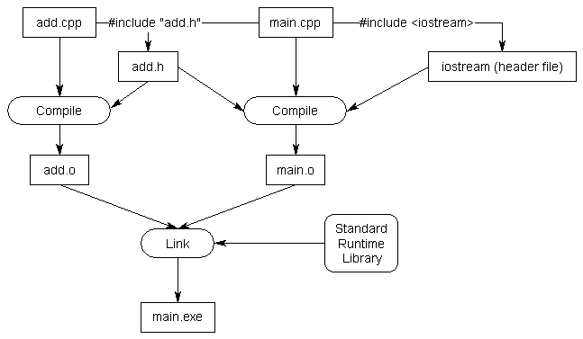

Compiling and Linking

Compile the program as follows:

```bash
g++ main.cpp add.h -c main.o
g++ add.cpp add.h -c add.o
g++ main.o add.o -o program
```

# 9 What’s next after this chapter

## 9.1 Things you can learn after this chapter

You can learn the following topics through

- Google Gemini using Guided Learning mode
- Website learncpp.com

Extra content to learn:

1. Naming collisions and an introduction to namespaces - [Click on this link](https://www.learncpp.com/cpp-tutorial/naming-collisions-and-an-introduction-to-namespaces/)
2. Introduction to preprocessor - [Click on this link](https://www.learncpp.com/cpp-tutorial/introduction-to-the-preprocessor/)
3. Header guards - [Click on this link](https://www.learncpp.com/cpp-tutorial/header-guards/)